# First benchmarks for live prediction in Dota 2

The data is downloaded from Kaggle: https://www.kaggle.com/devinanzelmo/dota-2-matches. We first load 3 data tables with live statistics for 50 000 dota matches.

```r
time_df = fread('C://Users/User/Documents/GitHub/dota/player_time.csv')
matches_df = fread("C://Users/User/Documents/GitHub/dota/match.csv")
player_df = fread("C://Users/User/Documents/GitHub/dota/players.csv")
```

Each match has a `match_id` in all three data tables, which allows joining the data tables. In other words, the three data tables contain additional information for these matches and the match id allows us to combine and aggregate that information.

We first are going to change the match ids to run in the range 1 … 50 000, not in the range 0 … 49 999.

```r
matches_df$match_id = matches_df$match_id + 1
time_df$match_id = time_df$match_id + 1
player_df$match_id = player_df$match_id + 1
```

Brief description of the datasets:

- `time_df`: Contains last hits, experience, and gold sampled at one minute interval for all players in all matches. The column names indicate the player_slot. For instance xp_t_1 indicates that this column has experience sums for the player in slot one.
- `mathces_df`: contains top level information about each match.
- `players_df`: Individual players are identified by `account_id` but there is an option to play anonymously and roughly one third of the `account_id` are not available. Anonymous users have the value of 0 for `account_id`. Contains totals for *kills*, *deaths*, *denies*, etc. Player action counts are available, and are indicated by variable names beginning with *unit_order_*. Counts for reasons for acquiring or losing gold, and gaining experience, have prefixes *gold_*, and *xp_*.

Let us next create a simple data frame `gold` containing the minute-by-minute information of the gold live statistics for each match.

```r
gold = data.table()
gold$minute = (time_df$times / 60)
gold$match_id = time_df$match_id
gold$radiant = time_df[, gold_t_0 + gold_t_1 + gold_t_2 + gold_t_3 + gold_t_4]
gold$dire = time_df[, gold_t_128 + gold_t_129 + gold_t_130 + gold_t_131 + gold_t_132]
```

This data frame gives for each match the gold score of radiant and dire teams minute by minute.

```r
gold = gold[minute > 0, ]
gold %>% head
```

| minute | match_id | radiant | dire |
| --- | --- | --- | --- |
| 1 | 1 | 1113 | 1370 |
| 2 | 1 | 2471 | 2726 |
| 3 | 1 | 3490 | 4057 |
| 4 | 1 | 4950 | 5500 |
| 5 | 1 | 5947 | 6984 |
| 6 | 1 | 7295 | 8426 |

We do the same for experience.

```r
xp = data.table()
xp$minute = (time_df$times / 60)
xp$match_id = time_df$match_id
xp$radiant = time_df[, xp_t_0 + xp_t_1 + xp_t_2 + xp_t_3 + xp_t_4]
xp$dire = time_df[, xp_t_128 + xp_t_129 + xp_t_130 + xp_t_131 + xp_t_132]

xp = xp[minute > 0, ]

xp %>%  tail
```

| minute | match_id | radiant | dire |
| --- | --- | --- | --- |
| 43 | 50000 | 103311 | 121968 |
| 44 | 50000 | 111552 | 123091 |
| 45 | 50000 | 112424 | 123091 |
| 46 | 50000 | 113319 | 126923 |
| 47 | 50000 | 113319 | 133645 |
| 48 | 50000 | 113319 | 133645 |

We now create a function for displaying the *gold* and *xp* live statistics minute by minute.

```r
display_match = function(id=1){
  dygraph(ts(cbind(gold[match_id==id, radiant-dire], xp[match_id==id, radiant-dire]), names = c('gold', 'xp')), main = paste('Match', id), xlab = 'minute')
}
```

Here is a typical example:

```r
#1299 599
display_match(10)
```

[interactive chart not shown]

Here we see an initial period where no side has a strong advantage after which one of the sides grows stronger monotonously.

Here is a less typical example with several reversals in game.

```r
#1299 599
display_match(1299)
```

[interactive chart not shown]

In order to make better analysis of the game outcomes, we need to know the typical duration of games.

### What is the distribution of match lengths?

First, lest us show all percentiles multiples of 10:

```r
min_ind = xp[minute==1, which = T]
min_ind = min_ind - 1
min_ind = min_ind[2:length(min_ind)]
min_ind = c(min_ind, nrow(gold))

minutes = gold$minute[min_ind]
quantile(minutes, seq(0,1,0.1))
```

```
##   0%  10%  20%  30%  40%  50%  60%  70%  80%  90% 100%
##    3   31   34   37   40   42   45   48   52   57  269
```

We see that 90% of the games in the data set are shorter than 57 minutes, but there are outliers with much longer duration. In order to show the histogram with game durations, we are going to trim all points above 75 by rounding them off to 75.

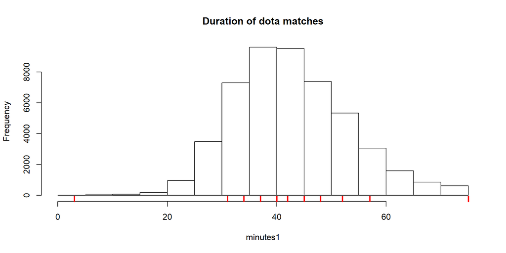

```r
#all matchels longer than 75 minutes are put in the bin 75
minutes1 = ifelse(minutes < 75, minutes, 75)

hist(minutes1, breaks = seq(0,75, 5), main = 'Duration of dota matches')
rug(quantile(minutes1, seq(0,1,0.1)),col=2, lwd=2.5)
```

The red ticks in the histogram indicate the percentiles multiples of 10.

### Computing the base predictors

We are going to use the momentary relative difference in gold and experience between the two teams as a predictor for the outcome of the match. That is, if the difference is positive then the prediction is that the radiant team will win, otherwise the predicted winner is the dire team.

First, we augment the data tables with the outcome of the matches. To do so, we need to join `gold` and `xp` with `matches_df`, as the latter data frame contains the match outcomes. We first do so for `gold`.

```r
#first, set the key by which we join the two data tables
setkey(gold, match_id)
setkey(matches_df, match_id)

#here we join the two tables
gold = gold[matches_df[, .(match_id, radiant_win)]]
print(gold, topn = 10, nrows = 100)
```

```
##          minute match_id radiant   dire radiant_win
##       1:      1        1    1113   1370        TRUE
##       2:      2        1    2471   2726        TRUE
##       3:      3        1    3490   4057        TRUE
##       4:      4        1    4950   5500        TRUE
##       5:      5        1    5947   6984        TRUE
##       6:      6        1    7295   8426        TRUE
##       7:      7        1    8544   9766        TRUE
##       8:      8        1   11017  11280        TRUE
##       9:      9        1   12646  12735        TRUE
##      10:     10        1   13844  14271        TRUE
##      ---
## 2159769:     39    50000   73482  91832       FALSE
## 2159770:     40    50000   76041  95350       FALSE
## 2159771:     41    50000   77424  97414       FALSE
## 2159772:     42    50000   79003 100909       FALSE
## 2159773:     43    50000   81638 111209       FALSE
## 2159774:     44    50000   88810 113934       FALSE
## 2159775:     45    50000   89979 114434       FALSE
## 2159776:     46    50000   91311 117625       FALSE
## 2159777:     47    50000   91556 123044       FALSE
## 2159778:     48    50000   91556 123044       FALSE
```

We next add the difference in gold as a new column. Then we add the column `predict` indicating whether our predictor is correct at each minute.

```r
gold$diff = gold$radiant - gold$dire
gold$predict = ifelse(((gold$diff > 0) & (gold$radiant_win == T)) | ((gold$diff < 0) & (gold$radiant_win == F)), T, F)
print(gold, topn = 10, nrows = 100)
```

```
##          minute match_id radiant   dire radiant_win   diff predict
##       1:      1        1    1113   1370        TRUE   -257   FALSE
##       2:      2        1    2471   2726        TRUE   -255   FALSE
##       3:      3        1    3490   4057        TRUE   -567   FALSE
##       4:      4        1    4950   5500        TRUE   -550   FALSE
##       5:      5        1    5947   6984        TRUE  -1037   FALSE
##       6:      6        1    7295   8426        TRUE  -1131   FALSE
##       7:      7        1    8544   9766        TRUE  -1222   FALSE
##       8:      8        1   11017  11280        TRUE   -263   FALSE
##       9:      9        1   12646  12735        TRUE    -89   FALSE
##      10:     10        1   13844  14271        TRUE   -427   FALSE
##      ---
## 2159769:     39    50000   73482  91832       FALSE -18350    TRUE
## 2159770:     40    50000   76041  95350       FALSE -19309    TRUE
## 2159771:     41    50000   77424  97414       FALSE -19990    TRUE
## 2159772:     42    50000   79003 100909       FALSE -21906    TRUE
## 2159773:     43    50000   81638 111209       FALSE -29571    TRUE
## 2159774:     44    50000   88810 113934       FALSE -25124    TRUE
## 2159775:     45    50000   89979 114434       FALSE -24455    TRUE
## 2159776:     46    50000   91311 117625       FALSE -26314    TRUE
## 2159777:     47    50000   91556 123044       FALSE -31488    TRUE
## 2159778:     48    50000   91556 123044       FALSE -31488    TRUE
```

For example, for the first 5 rows the predictor is wrong as the difference is negative or zero, but the radiant team eventually wins the game.

Let us compute the percentages of correct predictions for all matches and at all times:

```r
sum(gold$predict) / length(gold$predict)
```

```
## [1] 0.7297945
```

So, in 72.98% of the times the momentary gold difference correctly predicts the winner.

We now plot the percentage of correct predictions for each minute for all matches.

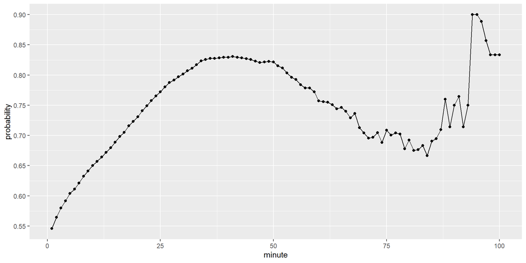

```r
pred_by_minute1 = gold[, .(probability = sum(predict) / length(predict)), by = minute]
ggplot(data = pred_by_minute1[1:100,], aes(minute, probability) ) + geom_point() + geom_line() +  scale_y_continuous(breaks = scales::pretty_breaks(n = 10))
```

So, we see that in the first minute this predictor is correct in 55% of the times. Since random guessing will gives us around 50% success rate, we see that in the beginning this predictor is close to random guessing. The predictor steadily improves with the progression of the game and reaches a peak at around the 40th minute. After that is starts to gradually decline.

*This decline needs to be explained.*

### Repeat the same arguments for xp

```r
setkey(xp, match_id)
setkey(matches_df, match_id)

xp = xp[matches_df[, .(match_id, radiant_win)]]
print(xp, topn=3)
```

```
##          minute match_id radiant   dire radiant_win
##       1:      1        1     692    692        TRUE
##       2:      2        1    2376   2318        TRUE
##       3:      3        1    3634   3543        TRUE
##      ---
## 2159776:     46    50000  113319 126923       FALSE
## 2159777:     47    50000  113319 133645       FALSE
## 2159778:     48    50000  113319 133645       FALSE
```

```r
xp$diff = xp$radiant - xp$dire
xp$predict = ifelse(((xp$diff > 0) & (xp$radiant_win == T)) | ((xp$diff < 0) & (xp$radiant_win == F)), T, F)
print(xp, topn=3)
```

```
##          minute match_id radiant   dire radiant_win   diff predict
##       1:      1        1     692    692        TRUE      0   FALSE
##       2:      2        1    2376   2318        TRUE     58    TRUE
##       3:      3        1    3634   3543        TRUE     91    TRUE
##      ---
## 2159776:     46    50000  113319 126923       FALSE -13604    TRUE
## 2159777:     47    50000  113319 133645       FALSE -20326    TRUE
## 2159778:     48    50000  113319 133645       FALSE -20326    TRUE
```

```r
sum(xp$predict) / length(xp$predict)
```

```
## [1] 0.7139132
```

We see that `xp` is a slightly weaker predictor than `gold`. We next show the percentage of correct predictions for each minute for `xp`.

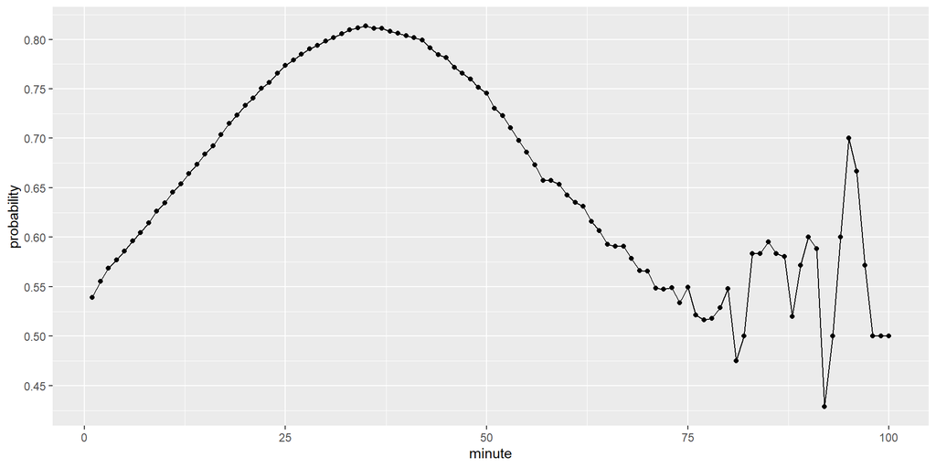

```r
pred_by_minute2 = xp[, .(probability = sum(predict) / length(predict)), by = minute]
ggplot(data = pred_by_minute2[1:100,], aes(minute, probability)) + geom_point() + geom_line() +  scale_y_continuous(breaks = scales::pretty_breaks(n = 10))
```

### We now compare the two predictiors in a single graph

We now join the two data frames with success rates into a single one.

```r
setkey(pred_by_minute1, 'minute')
setkey(pred_by_minute2, 'minute')
pred = pred_by_minute1[pred_by_minute2]
names(pred) = c('minute', 'gold', 'xp')
print(pred, topn=5)
```

```
##      minute      gold        xp
##   1:      1 0.5457400 0.5389400
##   2:      2 0.5645800 0.5554800
##   3:      3 0.5797800 0.5688400
##   4:      4 0.5916837 0.5769231
##   5:      5 0.6039483 0.5858669
##  ---
## 265:    265 1.0000000 1.0000000
## 266:    266 1.0000000 1.0000000
## 267:    267 1.0000000 1.0000000
## 268:    268 1.0000000 1.0000000
## 269:    269 1.0000000 1.0000000
```

We need to convert this data table in the *long* format in order to create the plot.

```r
predict_by_minute = melt(pred, id.vars = 'minute', value.name = 'probability')
predict_by_minute %>% print(topn=5)
```

```
##      minute variable probability
##   1:      1     gold   0.5457400
##   2:      2     gold   0.5645800
##   3:      3     gold   0.5797800
##   4:      4     gold   0.5916837
##   5:      5     gold   0.6039483
##  ---
## 534:    265       xp   1.0000000
## 535:    266       xp   1.0000000
## 536:    267       xp   1.0000000
## 537:    268       xp   1.0000000
## 538:    269       xp   1.0000000
```

This is the combined plot of the two curves.

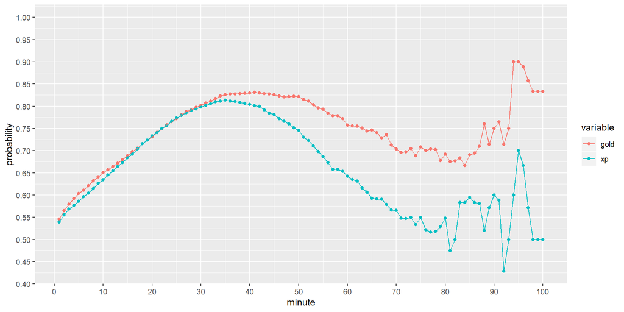

```r
gg = ggplot(data = predict_by_minute, aes(minute, probability, color = variable)) + geom_point() + geom_line() +  scale_y_continuous(breaks = scales::pretty_breaks(n = 10)) + scale_x_continuous(breaks = scales::pretty_breaks(n = 10),limits = c(1,100))

suppressWarnings(print(gg))
```

The fact that the quality of `xp` dips much lower than that of `gold` needs further analysis and some explanation.

## Further analysis

Let us find all matches with duration of at least 100 minutes. Their match ids are as follows:

```r
ix = gold[minute == 100, which=T]
ids = gold$match_id[ix]
ids
```

```
## [1]  1611  9947 10160 22047 26681 27374
```

Let us consider the following match:

```r
display_match(ids[2])
```

[interactive chart not shown]

At around minute 95 the two teams stop changing their difference in experience. The reason for this is likely to be that the experience statistics has a maximum after which it stops registering any changes.

```r
xp[match_id == ids[2]] %>% print(topn=4)
```

```
##      minute match_id radiant   dire radiant_win  diff predict
##   1:      1     9947     717    704       FALSE    13   FALSE
##   2:      2     9947    2001   2290       FALSE  -289    TRUE
##   3:      3     9947    3265   3904       FALSE  -639    TRUE
##   4:      4     9947    4331   5389       FALSE -1058    TRUE
##  ---
## 266:    266     9947  162520 164207       FALSE -1687    TRUE
## 267:    267     9947  162520 164207       FALSE -1687    TRUE
## 268:    268     9947  162520 164207       FALSE -1687    TRUE
## 269:    269     9947  162520 164207       FALSE -1687    TRUE
```

We see that the experience of each team is not changing in the last four minutes of the game, suggesting that they have reached their maximum experience.

### Restrict all matches to certain duration

We again join `gold` with `matches_id` to add a duration column to `gold`.

```r
setkey(matches_df, 'match_id')
setkey(gold, 'match_id')

gold = gold[matches_df[,.(match_id, duration)]]

gold %>% print(topn=5)
```

```
##          minute match_id radiant   dire radiant_win   diff predict duration
##       1:      1        1    1113   1370        TRUE   -257   FALSE     2375
##       2:      2        1    2471   2726        TRUE   -255   FALSE     2375
##       3:      3        1    3490   4057        TRUE   -567   FALSE     2375
##       4:      4        1    4950   5500        TRUE   -550   FALSE     2375
##       5:      5        1    5947   6984        TRUE  -1037   FALSE     2375
##      ---
## 2159774:     44    50000   88810 113934       FALSE -25124    TRUE     2788
## 2159775:     45    50000   89979 114434       FALSE -24455    TRUE     2788
## 2159776:     46    50000   91311 117625       FALSE -26314    TRUE     2788
## 2159777:     47    50000   91556 123044       FALSE -31488    TRUE     2788
## 2159778:     48    50000   91556 123044       FALSE -31488    TRUE     2788
```

Investigating the latter table reveals that in `time_df` and consequently i `gold` for each match contains around 2 minutes more that what is indicated by duration. For example, the match with `id=50 000’ has duration 2788/60 = 46 minutes and 28 seconds, but in the above table we have records up to the 48th minute. Except for the minutes, the values in the last two rows are also identical.

Now, we are going to select only those matches whose duration is between 40 and 50 minutes.

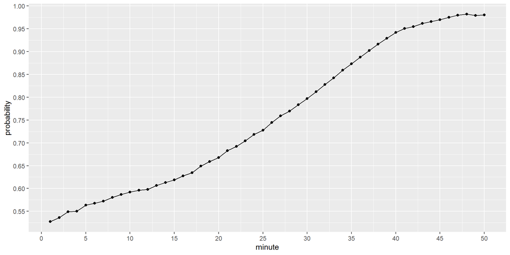

```r
#Substract 2 minutes to obtain the correct interval
#this is equivalent to adding 2 minutes to duration

dur1 = 60*(40 - 2)
dur2 = 60*(50 - 2)

pred_by_minute3 = gold[dur1 < duration  & duration <= dur2, .(probability = sum(predict) / length(predict)), by = minute]

ggplot(data = pred_by_minute3, aes(minute, probability)) + geom_point() + geom_line() +   scale_y_continuous(breaks = scales::pretty_breaks(n = 10)) + scale_x_continuous(breaks = scales::pretty_breaks(n = 10))
```

Let us look at the last data table more closely.

```r
pred_by_minute3 %>% tail
```

| minute | probability |
| --- | --- |
| 45 | 0.9696433 |
| 46 | 0.9754210 |
| 47 | 0.9798083 |
| 48 | 0.9820410 |
| 49 | 0.9794319 |
| 50 | 0.9805970 |

It is surprising that the accuracy did not go to 100% for the last minute. This requires further investigating.

### Investigating *tower statuses*

There is a description of the tower statuses at the end of the game on this page:

http://sharonkuo.me/dota2/matchdetails.html

``The tower status is represented by a 16-bit unsigned integer; the rightmost 11 bits represent individual towers for the team. The rightmost 11 bits represent the towers in the following order: ancient top tower, ancient bottom tower, bottom tier 3, bottom tier 2, bottom tier 1, middle tier 3, middle tier 2, middle tier 1, top tier 3, top tier 3, and top tier 1. For example, if the *tower_status_radiant* is 1572 in decimal (as in the example), then this is 0000011000100100 in binary. The first five bits do not matter, so we have 11000100100. This means that the Radiant still had their ancient top and bottom towers, as well as their middle and top tier 3 towers.’’

This means that a status code strictly less than 512 indicates that the two Ancient towers have been destroyed. Let us plot the distribution of tower codes in the data.

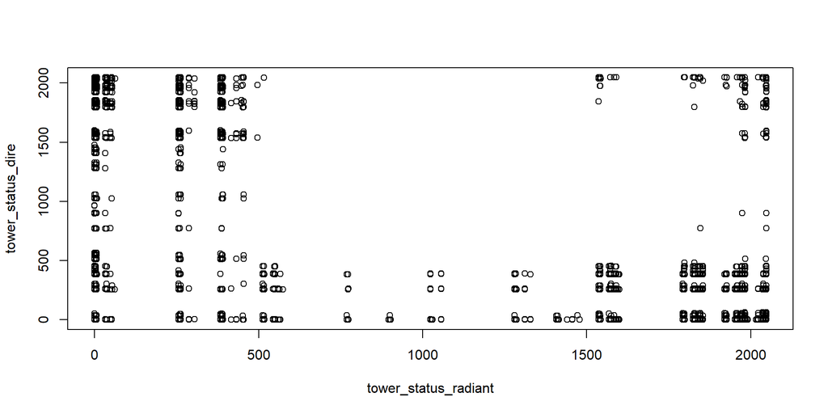

```r
matches_df[,.(tower_status_radiant, tower_status_dire)] %>% plot
```

The lower left corner of the above graph below 512 in both axes indicates game outcomes where the Ancient towers have been destroyed in both teams. *This requres further explanation.*

Let us also see a single game in which both tower statuses are less than 512:

```r
matches_df[match_id == 57]
```

| match_id | start_time | duration | tower_status_radiant | tower_status_dire | barracks_status_dire | barracks_status_radiant | first_blood_time | game_mode | radiant_win | negative_votes | positive_votes | cluster |
| --- | --- | --- | --- | --- | --- | --- | --- | --- | --- | --- | --- | --- |
| 57 | 1446986273 | 3514 | 0 | 454 | 51 | 3 | 5 | 22 | TRUE | 0 | 0 | 133 |

```r
display_match(57)
```

[interactive chart not shown]

Here are some match ids for which `gold` at the end of the match does not predict correctly the winner of the game.

40 57 233 242 282 308

We now join `xp` with `matches_id` to add a duration column to `xp`.

```r
setkey(matches_df, 'match_id')
setkey(xp , 'match_id')

xp = xp[matches_df[,.(match_id, duration)]]

xp %>% print(topn=5)
```

```
##          minute match_id radiant   dire radiant_win   diff predict duration
##       1:      1        1     692    692        TRUE      0   FALSE     2375
##       2:      2        1    2376   2318        TRUE     58    TRUE     2375
##       3:      3        1    3634   3543        TRUE     91    TRUE     2375
##       4:      4        1    5285   5007        TRUE    278    TRUE     2375
##       5:      5        1    6484   6574        TRUE    -90   FALSE     2375
##      ---
## 2159774:     44    50000  111552 123091       FALSE -11539    TRUE     2788
## 2159775:     45    50000  112424 123091       FALSE -10667    TRUE     2788
## 2159776:     46    50000  113319 126923       FALSE -13604    TRUE     2788
## 2159777:     47    50000  113319 133645       FALSE -20326    TRUE     2788
## 2159778:     48    50000  113319 133645       FALSE -20326    TRUE     2788
```

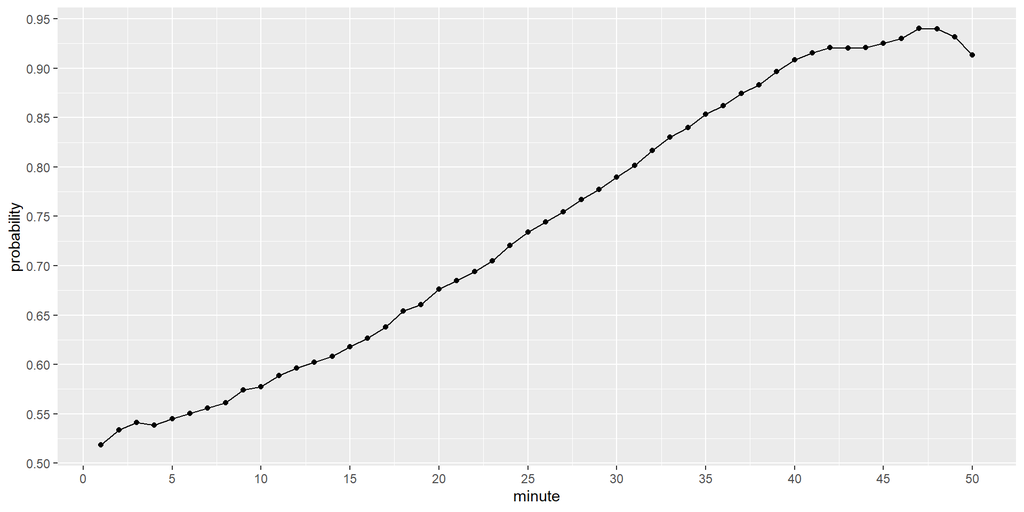

```r
#Substract 2 minutes to obtain the correct interval
#this is equivalent to adding 2 minutes to duration

dur1 = 60*(40 - 2)
dur2 = 60*(50 - 2)

pred_by_minute4 =xp[dur1 < duration  & duration <= dur2, .(probability = sum(predict) / length(predict)), by = minute]

ggplot(data = pred_by_minute4, aes(minute, probability)) + geom_point() + geom_line() +   scale_y_continuous(breaks = scales::pretty_breaks(n = 10)) + scale_x_continuous(breaks = scales::pretty_breaks(n = 10))
```

```r
pred_by_minute4 %>% tail
```

| minute | probability |
| --- | --- |
| 45 | 0.9252303 |
| 46 | 0.9302079 |
| 47 | 0.9402407 |
| 48 | 0.9398518 |
| 49 | 0.9314398 |
| 50 | 0.9134328 |